# Git, GitHub & Ocean Acidification

Jinghua Mu u7457359

2022-09-09

### **Question 9**:

Think about some things that can be improved in their code. List 3 things you think could be improved and provide a brief explanation for why.  
**MY ANSWER**

1. Using raw R script without rmarkdown makes it less readable between comments and code, and makes it impossible to run only parts of the code to make changes.
2. Using the original R package for plotting results in a huge amount of code and very low readability, making it difficult to identify the plotting process and statistical methods.
3. Doing a lot of statistical testing before plotting produces a lot of useless information. And because individual pieces of information aren’t combined into tables, it’s hard to compare different results.

### Reconstruct the OA picture

```r
# R script for analyses of activity levels #

#setwd('')

# import data
oaa <- read.csv('./OA_activitydat_20190302_BIOL3207.csv', header=TRUE)
# library(car)
# library(MASS)
```

```r
# format dataframe
{
oaa$comment <- as.character(oaa$comment)
oaa$animal_id <- as.character(oaa$animal_id)
oaa$animal_id <- as.integer(oaa$animal_id)
oaa$loc <- as.character(oaa$loc)
oaa$species <- as.character(oaa$species)
oaa$species <- tolower(oaa$species)
oaa$treatment <- relevel(as.factor(oaa$treatment), 'control')
}
```

```r
# figure for paper
library(scales)
library(plotrix)
# run one of these, then run from the brackets below

  ymin <- 0
  ymax <- 60
  ylab <- seq(from=ymin, to=ymax, by=10)

  layout(matrix(c(1,1,1,1,1,1,1,2,2,2,2,2,2,3,3,3,3,4,4,4,4,5,5,5,5,6,6,6,6), 1, 29))

  par(mar=c(1, 0, 0, 1), bty='n', oma=c(7, 7, 1, 0))

  # acanthos
  plot(NA, ylim=c(-3, ymax), xlim=c(0.4, 3.6), xaxt = 'n', yaxt = 'n')

  rect(-5000, -5000, 10000, 10000, col='grey92')
  abline(v = c(0.8, 1.2, 1.8, 2.2, 2.8, 3.2), lwd=3.6, col='white')
  abline(h = c(ylab), lwd=3.6, col='white')

  #2014
  foo <- oaa[oaa$species=='acantho' & oaa$loc=='LIRS 2014',]

  points(activity ~ jitter(as.numeric(treatment)-0.2, 11), data=foo[foo$treatment=='control',], lwd=1, pch=18, col = 'grey40', cex=1.1)
  points(activity ~ jitter(as.numeric(treatment)-0.8, 5.5), data=foo[foo$treatment=='CO2',], lwd=1, pch=16, col = 'dodgerblue2')

  axis(2, at = ylab, labels = ylab, lty=0, tick=NA, cex.axis=2, las=2)
  mtext(expression(paste('Activity duration (', 's min'^'-1', ')')), side=2, line=3.25, cex=2)

  #mtext(expression(italic('A. polyacanthus')), cex=1.5, side=3, line=1)

  text(0.6, 58, labels = 'A', cex=3.4, font=2)

  points(x = 0.8, y = mean(foo[foo$treatment=='control',]$activity), cex=2.6, pch=16, col = 'grey40')
  segments(x0 = 0.8, x1 = 0.8,
           y0 = mean(foo[foo$treatment=='control',]$activity) - (qnorm(0.975)*std.error(foo[foo$treatment=='control',]$activity)),
           y1 = mean(foo[foo$treatment=='control',]$activity) + (qnorm(0.975)*std.error(foo[foo$treatment=='control',]$activity)),
           lwd = 4, col = 'grey40')

  segments(x0 = 0.65, x1 = 0.95,
           y0 = mean(foo[foo$treatment=='control',]$activity) - (qnorm(0.975)*std.error(foo[foo$treatment=='control',]$activity)),
           y1 = mean(foo[foo$treatment=='control',]$activity) - (qnorm(0.975)*std.error(foo[foo$treatment=='control',]$activity)),
           lwd = 4, col = 'grey40')

  segments(x0 = 0.65, x1 = 0.95,
           y0 = mean(foo[foo$treatment=='control',]$activity) + (qnorm(0.975)*std.error(foo[foo$treatment=='control',]$activity)),
           y1 = mean(foo[foo$treatment=='control',]$activity) + (qnorm(0.975)*std.error(foo[foo$treatment=='control',]$activity)),
           lwd = 4, col = 'grey40')

  segments(x0 = 1.2, x1 = 1.2,
           y0 = mean(foo[foo$treatment=='CO2',]$activity) - (qnorm(0.975)*std.error(foo[foo$treatment=='CO2',]$activity)),
           y1 = mean(foo[foo$treatment=='CO2',]$activity) + (qnorm(0.975)*std.error(foo[foo$treatment=='CO2',]$activity)),
           lwd = 4, col = 'dodgerblue2')

  segments(x0 = 1.05, x1 = 1.35,
           y0 = mean(foo[foo$treatment=='CO2',]$activity) - (qnorm(0.975)*std.error(foo[foo$treatment=='CO2',]$activity)),
           y1 = mean(foo[foo$treatment=='CO2',]$activity) - (qnorm(0.975)*std.error(foo[foo$treatment=='CO2',]$activity)),
           lwd = 4, col = 'dodgerblue2')

  segments(x0 = 1.05, x1 = 1.35,
           y0 = mean(foo[foo$treatment=='CO2',]$activity) + (qnorm(0.975)*std.error(foo[foo$treatment=='CO2',]$activity)),
           y1 = mean(foo[foo$treatment=='CO2',]$activity) + (qnorm(0.975)*std.error(foo[foo$treatment=='CO2',]$activity)),
           lwd = 4, col = 'dodgerblue2')
  points(x = 1.2, y = mean(foo[foo$treatment=='CO2',]$activity), cex=2.6, pch=21, col = 'dodgerblue2', bg='white', lwd=4)

  axis(1, at = c(0.8, 1.2), labels = c('Control', expression(paste('CO'[2]))), lty=0, tick=NA, cex.axis=2, las=2)


  #2015
  foo <- oaa[oaa$species=='acantho' & oaa$loc=='AIMS 2015',]

  points(activity ~ jitter(as.numeric(treatment)+0.8, 3), data=foo[foo$treatment=='control',], lwd=1, pch=18, col = 'grey40', cex=1.1)
  points(activity ~ jitter(as.numeric(treatment)+0.2, 3), data=foo[foo$treatment=='CO2',], lwd=1, pch=16, col = 'dodgerblue2')

  points(x = 1.8, y = mean(foo[foo$treatment=='control',]$activity), cex=2.6, pch=16, col = 'grey40')
  segments(x0 = 1.8, x1 = 1.8,
           y0 = mean(foo[foo$treatment=='control',]$activity) - (qnorm(0.975)*std.error(foo[foo$treatment=='control',]$activity)),
           y1 = mean(foo[foo$treatment=='control',]$activity) + (qnorm(0.975)*std.error(foo[foo$treatment=='control',]$activity)),
           lwd = 4, col = 'grey40')

  segments(x0 = 1.65, x1 = 1.95,
           y0 = mean(foo[foo$treatment=='control',]$activity) - (qnorm(0.975)*std.error(foo[foo$treatment=='control',]$activity)),
           y1 = mean(foo[foo$treatment=='control',]$activity) - (qnorm(0.975)*std.error(foo[foo$treatment=='control',]$activity)),
           lwd = 4, col = 'grey40')

  segments(x0 = 1.65, x1 = 1.95,
           y0 = mean(foo[foo$treatment=='control',]$activity) + (qnorm(0.975)*std.error(foo[foo$treatment=='control',]$activity)),
           y1 = mean(foo[foo$treatment=='control',]$activity) + (qnorm(0.975)*std.error(foo[foo$treatment=='control',]$activity)),
           lwd = 4, col = 'grey40')


  segments(x0 = 2.2, x1 = 2.2,
           y0 = mean(foo[foo$treatment=='CO2',]$activity) - (qnorm(0.975)*std.error(foo[foo$treatment=='CO2',]$activity)),
           y1 = mean(foo[foo$treatment=='CO2',]$activity) + (qnorm(0.975)*std.error(foo[foo$treatment=='CO2',]$activity)),
           lwd = 4, col = 'dodgerblue2')

  segments(x0 = 2.05, x1 = 2.35,
           y0 = mean(foo[foo$treatment=='CO2',]$activity) - (qnorm(0.975)*std.error(foo[foo$treatment=='CO2',]$activity)),
           y1 = mean(foo[foo$treatment=='CO2',]$activity) - (qnorm(0.975)*std.error(foo[foo$treatment=='CO2',]$activity)),
           lwd = 4, col = 'dodgerblue2')

  segments(x0 = 2.05, x1 = 2.35,
           y0 = mean(foo[foo$treatment=='CO2',]$activity) + (qnorm(0.975)*std.error(foo[foo$treatment=='CO2',]$activity)),
           y1 = mean(foo[foo$treatment=='CO2',]$activity) + (qnorm(0.975)*std.error(foo[foo$treatment=='CO2',]$activity)),
           lwd = 4, col = 'dodgerblue2')
  points(x = 2.2, y = mean(foo[foo$treatment=='CO2',]$activity), cex=2.6, pch=21, col = 'dodgerblue2', bg='white', lwd=4)

  axis(1, at = c(1.8, 2.2), labels = c('Control', expression(paste('CO'[2]))), lty=0, tick=NA, cex.axis=2, las=2)
```

```r
  # 2016
  foo <- oaa[oaa$species=='acantho' & oaa$loc=='LIRS 2016',]

  points(activity ~ jitter(as.numeric(treatment)+1.8, 2), data=foo[foo$treatment=='control',], lwd=1, pch=18, col = 'grey40', cex=1.1)
  points(activity ~ jitter(as.numeric(treatment)+1.2, 2), data=foo[foo$treatment=='CO2',], lwd=1, pch=16, col = 'dodgerblue2')

  points(x = 2.8, y = mean(foo[foo$treatment=='control',]$activity), cex=2.6, pch=16, col = 'grey40')
  segments(x0 = 2.8, x1 = 2.8,
           y0 = mean(foo[foo$treatment=='control',]$activity) - (qnorm(0.975)*std.error(foo[foo$treatment=='control',]$activity)),
           y1 = mean(foo[foo$treatment=='control',]$activity) + (qnorm(0.975)*std.error(foo[foo$treatment=='control',]$activity)),
           lwd = 4, col = 'grey40')

  segments(x0 = 2.65, x1 = 2.95,
           y0 = mean(foo[foo$treatment=='control',]$activity) - (qnorm(0.975)*std.error(foo[foo$treatment=='control',]$activity)),
           y1 = mean(foo[foo$treatment=='control',]$activity) - (qnorm(0.975)*std.error(foo[foo$treatment=='control',]$activity)),
           lwd = 4, col = 'grey40')

  segments(x0 = 2.65, x1 = 2.95,
           y0 = mean(foo[foo$treatment=='control',]$activity) + (qnorm(0.975)*std.error(foo[foo$treatment=='control',]$activity)),
           y1 = mean(foo[foo$treatment=='control',]$activity) + (qnorm(0.975)*std.error(foo[foo$treatment=='control',]$activity)),
           lwd = 4, col = 'grey40')

  #points(x = 3.2, y = mean(foo[foo$treatment=='CO2',]$activity), cex=2.6, pch=16, col = 'dodgerblue2')
  segments(x0 = 3.2, x1 = 3.2,
           y0 = mean(foo[foo$treatment=='CO2',]$activity) - (qnorm(0.975)*std.error(foo[foo$treatment=='CO2',]$activity)),
           y1 = mean(foo[foo$treatment=='CO2',]$activity) + (qnorm(0.975)*std.error(foo[foo$treatment=='CO2',]$activity)),
           lwd = 4, col = 'dodgerblue2')

  segments(x0 = 3.05, x1 = 3.35,
           y0 = mean(foo[foo$treatment=='CO2',]$activity) - (qnorm(0.975)*std.error(foo[foo$treatment=='CO2',]$activity)),
           y1 = mean(foo[foo$treatment=='CO2',]$activity) - (qnorm(0.975)*std.error(foo[foo$treatment=='CO2',]$activity)),
           lwd = 4, col = 'dodgerblue2')

  segments(x0 = 3.05, x1 = 3.35,
           y0 = mean(foo[foo$treatment=='CO2',]$activity) + (qnorm(0.975)*std.error(foo[foo$treatment=='CO2',]$activity)),
           y1 = mean(foo[foo$treatment=='CO2',]$activity) + (qnorm(0.975)*std.error(foo[foo$treatment=='CO2',]$activity)),
           lwd = 4, col = 'dodgerblue2')
  points(x = 3.2, y = mean(foo[foo$treatment=='CO2',]$activity), cex=2.6, pch=21, col = 'dodgerblue2', bg='white', lwd=4)

  text(1,-3, labels='2014', cex=2)
  text(2,-3, labels='2015', cex=2)
  text(3,-3, labels='2016', cex=2)

  axis(1, at = c(2.8, 3.2), labels = c('Control', expression(paste('CO'[2]))), lty=0, tick=NA, cex.axis=2, las=2)




  # humbugs
  plot(NA, ylim=c(-3, ymax), xlim=c(0.4, 2.6), xaxt = 'n', yaxt = 'n')

  rect(-5000, -5000, 10000, 10000, col='grey92')
  abline(v = c(0.8, 1.2, 1.8, 2.2), lwd=3.6, col='white')
  abline(h = c(ylab), lwd=3.6, col='white')


  #2014

  foo <- oaa[oaa$species=='humbug' & oaa$loc=='LIRS 2014',]

  points(activity ~ jitter(as.numeric(treatment)-0.2, 11), data=foo[foo$treatment=='control',], lwd=1, pch=18, col = 'grey40', cex=1.1)
  points(activity ~ jitter(as.numeric(treatment)-0.8, 5.5), data=foo[foo$treatment=='CO2',], lwd=1, pch=16, col = 'dodgerblue2')

  #mtext(expression(italic('D. aruanus')), cex=1.5, side=3, line=1)

  text(0.6, 58, labels = 'B', cex=3.4, font=2)

  points(x = 0.8, y = mean(foo[foo$treatment=='control',]$activity), cex=2.6, pch=16, col = 'grey40')
  segments(x0 = 0.8, x1 = 0.8,
           y0 = mean(foo[foo$treatment=='control',]$activity) - (qnorm(0.975)*std.error(foo[foo$treatment=='control',]$activity)),
           y1 = mean(foo[foo$treatment=='control',]$activity) + (qnorm(0.975)*std.error(foo[foo$treatment=='control',]$activity)),
           lwd = 4, col = 'grey40')

  segments(x0 = 0.65, x1 = 0.95,
           y0 = mean(foo[foo$treatment=='control',]$activity) - (qnorm(0.975)*std.error(foo[foo$treatment=='control',]$activity)),
           y1 = mean(foo[foo$treatment=='control',]$activity) - (qnorm(0.975)*std.error(foo[foo$treatment=='control',]$activity)),
           lwd = 4, col = 'grey40')

  segments(x0 = 0.65, x1 = 0.95,
           y0 = mean(foo[foo$treatment=='control',]$activity) + (qnorm(0.975)*std.error(foo[foo$treatment=='control',]$activity)),
           y1 = mean(foo[foo$treatment=='control',]$activity) + (qnorm(0.975)*std.error(foo[foo$treatment=='control',]$activity)),
           lwd = 4, col = 'grey40')

  #points(x = 1.2, y = mean(foo[foo$treatment=='CO2',]$activity), cex=2.6, pch=16, col = 'dodgerblue2')
  segments(x0 = 1.2, x1 = 1.2,
           y0 = mean(foo[foo$treatment=='CO2',]$activity) - (qnorm(0.975)*std.error(foo[foo$treatment=='CO2',]$activity)),
           y1 = mean(foo[foo$treatment=='CO2',]$activity) + (qnorm(0.975)*std.error(foo[foo$treatment=='CO2',]$activity)),
           lwd = 4, col = 'dodgerblue2')

  segments(x0 = 1.05, x1 = 1.35,
           y0 = mean(foo[foo$treatment=='CO2',]$activity) - (qnorm(0.975)*std.error(foo[foo$treatment=='CO2',]$activity)),
           y1 = mean(foo[foo$treatment=='CO2',]$activity) - (qnorm(0.975)*std.error(foo[foo$treatment=='CO2',]$activity)),
           lwd = 4, col = 'dodgerblue2')

  segments(x0 = 1.05, x1 = 1.35,
           y0 = mean(foo[foo$treatment=='CO2',]$activity) + (qnorm(0.975)*std.error(foo[foo$treatment=='CO2',]$activity)),
           y1 = mean(foo[foo$treatment=='CO2',]$activity) + (qnorm(0.975)*std.error(foo[foo$treatment=='CO2',]$activity)),
           lwd = 4, col = 'dodgerblue2')
  points(x = 1.2, y = mean(foo[foo$treatment=='CO2',]$activity), cex=2.6, pch=21, col = 'dodgerblue2', bg='white', lwd=4)



  # 2016

  foo <- oaa[oaa$species=='humbug' & oaa$loc=='LIRS 2016',]

  points(activity ~ jitter(as.numeric(treatment)+0.8, 3), data=foo[foo$treatment=='control',], lwd=1, pch=18, col = 'grey40', cex=1.1)
  points(activity ~ jitter(as.numeric(treatment)+0.2, 3), data=foo[foo$treatment=='CO2',], lwd=1, pch=16, col = 'dodgerblue2')
```

```r
  points(x = 1.8, y = mean(foo[foo$treatment=='control',]$activity), cex=2.6, pch=16, col = 'grey40')
  segments(x0 = 1.8, x1 = 1.8,
           y0 = mean(foo[foo$treatment=='control',]$activity) - (qnorm(0.975)*std.error(foo[foo$treatment=='control',]$activity)),
           y1 = mean(foo[foo$treatment=='control',]$activity) + (qnorm(0.975)*std.error(foo[foo$treatment=='control',]$activity)),
           lwd = 4, col = 'grey40')

  segments(x0 = 1.65, x1 = 1.95,
           y0 = mean(foo[foo$treatment=='control',]$activity) - (qnorm(0.975)*std.error(foo[foo$treatment=='control',]$activity)),
           y1 = mean(foo[foo$treatment=='control',]$activity) - (qnorm(0.975)*std.error(foo[foo$treatment=='control',]$activity)),
           lwd = 4, col = 'grey40')

  segments(x0 = 1.65, x1 = 1.95,
           y0 = mean(foo[foo$treatment=='control',]$activity) + (qnorm(0.975)*std.error(foo[foo$treatment=='control',]$activity)),
           y1 = mean(foo[foo$treatment=='control',]$activity) + (qnorm(0.975)*std.error(foo[foo$treatment=='control',]$activity)),
           lwd = 4, col = 'grey40')

  #points(x = 2.2, y = mean(foo[foo$treatment=='CO2',]$activity), cex=2.6, pch=16, col = 'dodgerblue2')
  segments(x0 = 2.2, x1 = 2.2,
           y0 = mean(foo[foo$treatment=='CO2',]$activity) - (qnorm(0.975)*std.error(foo[foo$treatment=='CO2',]$activity)),
           y1 = mean(foo[foo$treatment=='CO2',]$activity) + (qnorm(0.975)*std.error(foo[foo$treatment=='CO2',]$activity)),
           lwd = 4, col = 'dodgerblue2')

  segments(x0 = 2.05, x1 = 2.35,
           y0 = mean(foo[foo$treatment=='CO2',]$activity) - (qnorm(0.975)*std.error(foo[foo$treatment=='CO2',]$activity)),
           y1 = mean(foo[foo$treatment=='CO2',]$activity) - (qnorm(0.975)*std.error(foo[foo$treatment=='CO2',]$activity)),
           lwd = 4, col = 'dodgerblue2')

  segments(x0 = 2.05, x1 = 2.35,
           y0 = mean(foo[foo$treatment=='CO2',]$activity) + (qnorm(0.975)*std.error(foo[foo$treatment=='CO2',]$activity)),
           y1 = mean(foo[foo$treatment=='CO2',]$activity) + (qnorm(0.975)*std.error(foo[foo$treatment=='CO2',]$activity)),
           lwd = 4, col = 'dodgerblue2')
  points(x = 2.2, y = mean(foo[foo$treatment=='CO2',]$activity), cex=2.6, pch=21, col = 'dodgerblue2', bg='white', lwd=4)


  text(1,-3, labels='2015', cex=2)
  text(2,-3, labels='2016', cex=2)

  axis(1, at = c(1.8, 2.2), labels = c('Control', expression(paste('CO'[2]))), lty=0, tick=NA, cex.axis=2, las=2)
  axis(1, at = c(0.8, 1.2), labels = c('Control', expression(paste('CO'[2]))), lty=0, tick=NA, cex.axis=2, las=2)



  # chromis
  plot(NA, ylim=c(-3, ymax), xlim=c(0.4, 2.6), xaxt = 'n', yaxt = 'n')

  rect(-5000, -5000, 10000, 10000, col='grey92')
  abline(v = c(1:2), lwd=3.6, col='white')
  abline(h = c(ylab), lwd=3.6, col='white')
  #points(activity ~ jitter(as.numeric(treatment), 1.2), data=oaa[oaa$species=='chromis',], lwd=1, pch=1)
  foo <- oaa[oaa$species=='chromis',]

  points(activity ~ jitter(as.numeric(treatment), 10), data=foo[foo$treatment=='control',], lwd=1, pch=18, col = 'grey40', cex=1.1)
  points(activity ~ jitter(as.numeric(treatment), 5), data=foo[foo$treatment=='CO2',], lwd=1, pch=16, col = 'dodgerblue2')

  #mtext(expression(italic('C. atripectoralis')), cex=1.5, side=3, line=1)
  axis(1, at = c(1,2), labels = c('Control', expression(paste('CO'[2]))), lty=0, tick=NA, cex.axis=2, las=2)

  text(1.5,-3, labels='2014', cex=2)
  text(0.6, 58, labels = 'C', cex=3.4, font=2)

  points(x = 1, y = mean(foo[foo$treatment=='control',]$activity), cex=2.6, pch=16, col = 'grey40')
  segments(x0 = 1, x1 = 1,
           y0 = mean(foo[foo$treatment=='control',]$activity) - (qnorm(0.975)*std.error(foo[foo$treatment=='control',]$activity)),
           y1 = mean(foo[foo$treatment=='control',]$activity) + (qnorm(0.975)*std.error(foo[foo$treatment=='control',]$activity)),
           lwd = 4, col = 'grey40')

  segments(x0 = 0.8, x1 = 1.2,
           y0 = mean(foo[foo$treatment=='control',]$activity) - (qnorm(0.975)*std.error(foo[foo$treatment=='control',]$activity)),
           y1 = mean(foo[foo$treatment=='control',]$activity) - (qnorm(0.975)*std.error(foo[foo$treatment=='control',]$activity)),
           lwd = 4, col = 'grey40')

  segments(x0 = 0.8, x1 = 1.2,
           y0 = mean(foo[foo$treatment=='control',]$activity) + (qnorm(0.975)*std.error(foo[foo$treatment=='control',]$activity)),
           y1 = mean(foo[foo$treatment=='control',]$activity) + (qnorm(0.975)*std.error(foo[foo$treatment=='control',]$activity)),
           lwd = 4, col = 'grey40')

  #points(x = 2, y = mean(foo[foo$treatment=='CO2',]$activity), cex=2.6, pch=16, col = 'dodgerblue2')
  segments(x0 = 2, x1 = 2,
           y0 = mean(foo[foo$treatment=='CO2',]$activity) - qnorm(0.975)*std.error(foo[foo$treatment=='CO2',]$activity),
           y1 = mean(foo[foo$treatment=='CO2',]$activity) + qnorm(0.975)*std.error(foo[foo$treatment=='CO2',]$activity),
           lwd = 4, col = 'dodgerblue2')

  segments(x0 = 1.8, x1 = 2.2,
           y0 = mean(foo[foo$treatment=='CO2',]$activity) - (qnorm(0.975)*std.error(foo[foo$treatment=='CO2',]$activity)),
           y1 = mean(foo[foo$treatment=='CO2',]$activity) - (qnorm(0.975)*std.error(foo[foo$treatment=='CO2',]$activity)),
           lwd = 4, col = 'dodgerblue2')

  segments(x0 = 1.8, x1 = 2.2,
           y0 = mean(foo[foo$treatment=='CO2',]$activity) + (qnorm(0.975)*std.error(foo[foo$treatment=='CO2',]$activity)),
           y1 = mean(foo[foo$treatment=='CO2',]$activity) + (qnorm(0.975)*std.error(foo[foo$treatment=='CO2',]$activity)),
           lwd = 4, col = 'dodgerblue2')
  points(x = 2, y = mean(foo[foo$treatment=='CO2',]$activity), cex=2.6, pch=21, col = 'dodgerblue2', bg='white', lwd=4)


  # ambon
  plot(NA, ylim=c(-3, ymax), xlim=c(0.4, 2.6), xaxt = 'n', yaxt = 'n')

  rect(-5000, -5000, 10000, 10000, col='grey92')
  abline(v = c(1:2), lwd=3.6, col='white')
  abline(h = c(ylab), lwd=3.6, col='white')
  #points(activity ~ jitter(as.numeric(treatment), 1.2), data=oaa[oaa$species=='ambon',], lwd=1, pch=1)
  foo <- oaa[oaa$species=='ambon',]
```

```r
  points(activity ~ jitter(as.numeric(treatment), 10), data=foo[foo$treatment=='control',], lwd=1, pch=18, col = 'grey40', cex=1.1)
  points(activity ~ jitter(as.numeric(treatment), 5), data=foo[foo$treatment=='CO2',], lwd=1, pch=16, col = 'dodgerblue2')

  mtext(expression(italic('P. amboinensis')), cex=1.5, side=3, line=1)
  axis(1, at = c(1,2), labels = c('Control', expression(paste('CO'[2]))), lty=0, tick=NA, cex.axis=2, las=2)
  text(1.5,-3, labels='2014', cex=2)
  text(0.6, 58, labels = 'D', cex=3.4, font=2)


  points(x = 1, y = mean(foo[foo$treatment=='control',]$activity), cex=2.6, pch=16, col = 'grey40')
  segments(x0 = 1, x1 = 1,
           y0 = mean(foo[foo$treatment=='control',]$activity) - (qnorm(0.975)*std.error(foo[foo$treatment=='control',]$activity)),
           y1 = mean(foo[foo$treatment=='control',]$activity) + (qnorm(0.975)*std.error(foo[foo$treatment=='control',]$activity)),
           lwd = 4, col = 'grey40')

  segments(x0 = 0.8, x1 = 1.2,
           y0 = mean(foo[foo$treatment=='control',]$activity) - (qnorm(0.975)*std.error(foo[foo$treatment=='control',]$activity)),
           y1 = mean(foo[foo$treatment=='control',]$activity) - (qnorm(0.975)*std.error(foo[foo$treatment=='control',]$activity)),
           lwd = 4, col = 'grey40')

  segments(x0 = 0.8, x1 = 1.2,
           y0 = mean(foo[foo$treatment=='control',]$activity) + (qnorm(0.975)*std.error(foo[foo$treatment=='control',]$activity)),
           y1 = mean(foo[foo$treatment=='control',]$activity) + (qnorm(0.975)*std.error(foo[foo$treatment=='control',]$activity)),
           lwd = 4, col = 'grey40')

  #points(x = 2, y = mean(foo[foo$treatment=='CO2',]$activity), cex=2.6, pch=16, col = 'dodgerblue2')
  segments(x0 = 2, x1 = 2,
           y0 = mean(foo[foo$treatment=='CO2',]$activity) - (qnorm(0.975)*std.error(foo[foo$treatment=='CO2',]$activity)),
           y1 = mean(foo[foo$treatment=='CO2',]$activity) + (qnorm(0.975)*std.error(foo[foo$treatment=='CO2',]$activity)),
           lwd = 4, col = 'dodgerblue2')

  segments(x0 = 1.8, x1 = 2.2,
           y0 = mean(foo[foo$treatment=='CO2',]$activity) - (qnorm(0.975)*std.error(foo[foo$treatment=='CO2',]$activity)),
           y1 = mean(foo[foo$treatment=='CO2',]$activity) - (qnorm(0.975)*std.error(foo[foo$treatment=='CO2',]$activity)),
           lwd = 4, col = 'dodgerblue2')

  segments(x0 = 1.8, x1 = 2.2,
           y0 = mean(foo[foo$treatment=='CO2',]$activity) + (qnorm(0.975)*std.error(foo[foo$treatment=='CO2',]$activity)),
           y1 = mean(foo[foo$treatment=='CO2',]$activity) + (qnorm(0.975)*std.error(foo[foo$treatment=='CO2',]$activity)),
           lwd = 4, col = 'dodgerblue2')
  points(x = 2, y = mean(foo[foo$treatment=='CO2',]$activity), cex=2.6, pch=21, col = 'dodgerblue2', bg='white', lwd=4)


  # lemon damsel
  plot(NA, ylim=c(-3, ymax), xlim=c(0.4, 2.6), xaxt = 'n', yaxt = 'n')

  rect(-5000, -5000, 10000, 10000, col='grey92')
  abline(v = c(1:2), lwd=3.6, col='white')
  abline(h = c(ylab), lwd=3.6, col='white')
  #points(activity ~ jitter(as.numeric(treatment), 1.2), data=oaa[oaa$species=='lemon',], lwd=1, pch=1)
  foo <- oaa[oaa$species=='lemon',]

  points(activity ~ jitter(as.numeric(treatment), 10), data=foo[foo$treatment=='control',], lwd=1, pch=18, col = 'grey40', cex=1.1)
  points(activity ~ jitter(as.numeric(treatment), 5), data=foo[foo$treatment=='CO2',], lwd=1, pch=16, col = 'dodgerblue2')

  text(0.6, 58, labels = 'E', cex=3.4, font=2)

  # mtext(expression(italic('P. moluccensis')), cex=1.5, side=3, line=1)
  axis(1, at = c(1,2), labels = c('Control', expression(paste('CO'[2]))), lty=0, tick=NA, cex.axis=2, las=2)
  text(1.5,-3, labels='2014', cex=2)


  points(x = 1, y = mean(foo[foo$treatment=='control',]$activity), cex=2.6, pch=16, col = 'grey40')
  segments(x0 = 1, x1 = 1,
           y0 = mean(foo[foo$treatment=='control',]$activity) - (qnorm(0.975)*std.error(foo[foo$treatment=='control',]$activity)),
           y1 = mean(foo[foo$treatment=='control',]$activity) + (qnorm(0.975)*std.error(foo[foo$treatment=='control',]$activity)),
           lwd = 4, col = 'grey40')

  segments(x0 = 0.8, x1 = 1.2,
           y0 = mean(foo[foo$treatment=='control',]$activity) - (qnorm(0.975)*std.error(foo[foo$treatment=='control',]$activity)),
           y1 = mean(foo[foo$treatment=='control',]$activity) - (qnorm(0.975)*std.error(foo[foo$treatment=='control',]$activity)),
           lwd = 4, col = 'grey40')

  segments(x0 = 0.8, x1 = 1.2,
           y0 = mean(foo[foo$treatment=='control',]$activity) + (qnorm(0.975)*std.error(foo[foo$treatment=='control',]$activity)),
           y1 = mean(foo[foo$treatment=='control',]$activity) + (qnorm(0.975)*std.error(foo[foo$treatment=='control',]$activity)),
           lwd = 4, col = 'grey40')

  #points(x = 2, y = mean(foo[foo$treatment=='CO2',]$activity), cex=2.6, pch=16, col = 'dodgerblue2')
  segments(x0 = 2, x1 = 2,
           y0 = mean(foo[foo$treatment=='CO2',]$activity) - (qnorm(0.975)*std.error(foo[foo$treatment=='CO2',]$activity)),
           y1 = mean(foo[foo$treatment=='CO2',]$activity) + (qnorm(0.975)*std.error(foo[foo$treatment=='CO2',]$activity)),
           lwd = 4, col = 'dodgerblue2')

  segments(x0 = 1.8, x1 = 2.2,
           y0 = mean(foo[foo$treatment=='CO2',]$activity) - (qnorm(0.975)*std.error(foo[foo$treatment=='CO2',]$activity)),
           y1 = mean(foo[foo$treatment=='CO2',]$activity) - (qnorm(0.975)*std.error(foo[foo$treatment=='CO2',]$activity)),
           lwd = 4, col = 'dodgerblue2')

  segments(x0 = 1.8, x1 = 2.2,
           y0 = mean(foo[foo$treatment=='CO2',]$activity) + (qnorm(0.975)*std.error(foo[foo$treatment=='CO2',]$activity)),
           y1 = mean(foo[foo$treatment=='CO2',]$activity) + (qnorm(0.975)*std.error(foo[foo$treatment=='CO2',]$activity)),
           lwd = 4, col = 'dodgerblue2')
  points(x = 2, y = mean(foo[foo$treatment=='CO2',]$activity), cex=2.6, pch=21, col = 'dodgerblue2', bg='white', lwd=4)



  # white damsels
  plot(NA, ylim=c(-3, ymax), xlim=c(0.4, 2.6), xaxt = 'n', yaxt = 'n')
```

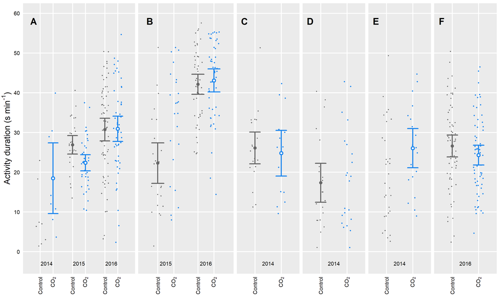

```r
  rect(-5000, -5000, 10000, 10000, col='grey92')
  abline(v = c(1:2), lwd=3.6, col='white')
  abline(h = c(ylab), lwd=3.6, col='white')
  #points(activity ~ jitter(as.numeric(treatment), 1.2), data=oaa[oaa$species=='whitedams',], lwd=1, pch=1)
  foo <- oaa[oaa$species=='whitedams',]

  points(activity ~ jitter(as.numeric(treatment), 10), data=foo[foo$treatment=='control',], lwd=1, pch=18, col = 'grey40', cex=1.1)
  points(activity ~ jitter(as.numeric(treatment), 5), data=foo[foo$treatment=='CO2',], lwd=1, pch=16, col = 'dodgerblue2')

  #mtext(expression(italic('D. perspicillatus')), cex=1.5, side=3, line=1)
  axis(1, at = c(1,2), labels = c('Control', expression(paste('CO'[2]))), lty=0, tick=NA, cex.axis=2, las=2)

  text(0.6, 58, labels = 'F', cex=3.4, font=2)
  text(1.5,-3, labels='2016', cex=2)

  points(x = 1, y = mean(foo[foo$treatment=='control',]$activity), cex=2.6, pch=16, col = 'grey40')
  segments(x0 = 1, x1 = 1,
           y0 = mean(foo[foo$treatment=='control',]$activity) - (qnorm(0.975)*std.error(foo[foo$treatment=='control',]$activity)),
           y1 = mean(foo[foo$treatment=='control',]$activity) + (qnorm(0.975)*std.error(foo[foo$treatment=='control',]$activity)),
           lwd = 4, col = 'grey40')

  segments(x0 = 0.8, x1 = 1.2,
           y0 = mean(foo[foo$treatment=='control',]$activity) - (qnorm(0.975)*std.error(foo[foo$treatment=='control',]$activity)),
           y1 = mean(foo[foo$treatment=='control',]$activity) - (qnorm(0.975)*std.error(foo[foo$treatment=='control',]$activity)),
           lwd = 4, col = 'grey40')

  segments(x0 = 0.8, x1 = 1.2,
           y0 = mean(foo[foo$treatment=='control',]$activity) + (qnorm(0.975)*std.error(foo[foo$treatment=='control',]$activity)),
           y1 = mean(foo[foo$treatment=='control',]$activity) + (qnorm(0.975)*std.error(foo[foo$treatment=='control',]$activity)),
           lwd = 4, col = 'grey40')

  #points(x = 2, y = mean(foo[foo$treatment=='CO2',]$activity), cex=2.6, pch=16, col = 'dodgerblue2')
  segments(x0 = 2, x1 = 2,
           y0 = mean(foo[foo$treatment=='CO2',]$activity) - qnorm(0.975)*std.error(foo[foo$treatment=='CO2',]$activity),
           y1 = mean(foo[foo$treatment=='CO2',]$activity) + qnorm(0.975)*std.error(foo[foo$treatment=='CO2',]$activity),
           lwd = 4, col = 'dodgerblue2')

  segments(x0 = 1.8, x1 = 2.2,
           y0 = mean(foo[foo$treatment=='CO2',]$activity) - (qnorm(0.975)*std.error(foo[foo$treatment=='CO2',]$activity)),
           y1 = mean(foo[foo$treatment=='CO2',]$activity) - (qnorm(0.975)*std.error(foo[foo$treatment=='CO2',]$activity)),
           lwd = 4, col = 'dodgerblue2')

  segments(x0 = 1.8, x1 = 2.2,
           y0 = mean(foo[foo$treatment=='CO2',]$activity) + (qnorm(0.975)*std.error(foo[foo$treatment=='CO2',]$activity)),
           y1 = mean(foo[foo$treatment=='CO2',]$activity) + (qnorm(0.975)*std.error(foo[foo$treatment=='CO2',]$activity)),
           lwd = 4, col = 'dodgerblue2')
  points(x = 2, y = mean(foo[foo$treatment=='CO2',]$activity), cex=2.6, pch=21, col = 'dodgerblue2', bg='white', lwd=4)
```

### My own try

```r
library(tidyverse)
```

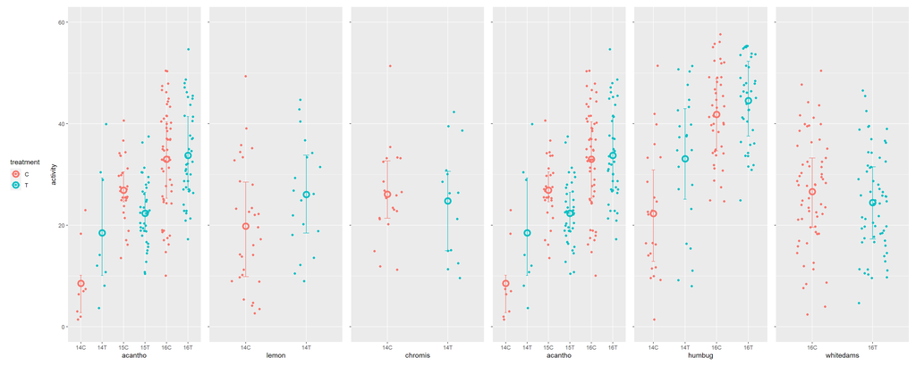

```r
library(patchwork)
q25 <-function(x){quantile(x,0.25)}
q75 <-function(x){quantile(x,0.75)}
oaa$loc = as.factor(oaa$loc)
oaa$loc = factor(oaa$loc, labels = c("15","14","16"))
oaa$treatment <- factor(as.factor(oaa$treatment), labels = c("C","T"))
pic <- function(selecting, notfirst = TRUE){
    data <- oaa %>% filter(species == selecting) %>% drop_na() %>% select(-comment,-X)
    data1 <- data %>% mutate(treat = treatment) %>% unite(col = "group", c(loc, treat), sep = "")
    stat <- data %>% group_by(loc,treatment) %>% summarise(mean = mean(activity), q25 = q25(activity),q75 = q75(activity),.groups = "drop") %>% mutate(treat = treatment) %>%
    unite(col = "group", c(loc, treat), sep = "")
    p1 <- ggplot(data = data1,aes(x = group, colour = treatment)) + geom_blank(aes(y = activity)) + geom_jitter(aes(y = activity), width = 0.25) +
    geom_errorbar(data = stat, aes(ymin = q25, ymax = q75),width = 0.1, position = position_dodge2(width = 0.5, padding = 0.5)) +
    geom_point(data = stat, aes(x = group, y = mean),size = 3,shape = 21,stroke = 2) + theme(legend.position = "left", plot.title = element_text(margin = margin())) + xlab(selecting) +ylim(c(0,60))
    if (notfirst == TRUE){
    p1 <- p1 + theme(legend.position="none", axis.text.y = element_blank()) + ylab(NULL)
    }
    p1
}
pic("acantho", notfirst = FALSE) | pic('lemon') |pic('chromis') | pic('acantho') | pic('humbug') | pic('whitedams')
```

### **Question 10**

What are the challenges, if any, that you encounter in reproducing this figure?  
**MY ANSWER**  
1. On the native ggplot, it is difficult to achieve two groupings at the same time on one drawing and label them on different levels of labels, so I can only group them in sequence instead.  
2. The function of the `patchwork` package is too simple to set the specific width of each image, and it is not compatible with the image output size setting of rmarkdown, so it is difficult to draw images of the appropriate scale.